# Who said what EC: A basis for analyses

Jérémy Béna

# Load packages and read the data

```r
#Load (or install and load) packages
require(pacman)
p_load('tidyverse', 'psych', 'effectsize', 'afex', 'bfrr', 'papaja', 'kableExtra', 'MPTinR', 'TreeBUGS')
set_sum_contrasts()

#read the dataset we created in a previous R script
dat = readRDS("C:/Users/benaj/OneDrive - UCL/Postdoctorat/projects_Karoline/study/test_study/pilot_study/data/data_wsw_final_pilot.RDS")

#some factors are integer or character variables in the dataset; make them factors
dat$url.srid = as.factor(dat$url.srid)
dat$cs_category = as.factor(dat$cs_category)
dat$us_valence = as.factor(dat$us_valence)
dat$reco_resp = as.factor(dat$reco_resp)
```

# Exclude participants

```r
#exclude participants declaring they did not take their responses seriously
##or did not pay attention
dat = dat %>% filter(pay_attention != 0 & serious != 0) %>% droplevels() #drop level to remove excluded ppts
length(unique(dat$url.srid)) # N of participants after exclusion
```

```
[1] 49
```

# Code responses in the recognition/CS-US pairing memory tasks

```r
#create a new factor to distinguish between old and new CSs
dat$cs_exposure = ifelse(dat$us_valence == "dist", "new", "old")
table(dat$cs_exposure, dat$us_valence)
```

```
      dist negative positive
  new 1176        0        0
  old    0      588      588
```

```r
#indicate whether the recognition decision is correct (hit and cr) or not (fa and miss)
dat = dat %>%
  mutate(reco_accuracy = ifelse((cs_exposure=="old" & reco_resp == "old"), "hit"
                                ,ifelse((cs_exposure=="old" & reco_resp == "new"), "miss"
                                ,ifelse((cs_exposure=="new" & reco_resp == "old"), "fa", "cr"))
                                ))

#indicate whether source memory is correct regarding valence (positive or negative)
dat$correct_us_source = NA
dat$source_mem_resp = NA

for(i in 1:length(dat$url.srid)){
  dat$correct_us_source[i] = dat$uss[[i]][dat$idtarg[i]+1]
  dat$source_mem_resp[i] = dat$uss[[i]][as.numeric(substr(dat$source_mem, 3, 3))[i]]
}

#calculate whether us valence and us identity memory are correct or not
dat = dat %>%
  mutate(val_us_accuracy = ifelse(substr(source_mem_resp, 0, 1) == substr(correct_us_source, 0, 1), "val_correct", "val_incorrect")
        ,id_us_accuracy = ifelse(source_mem_resp == correct_us_source, "id_correct", "id_incorrect")
         )

table(dat$val_us_accuracy)
```

```
  val_correct val_incorrect
          516           118
```

```r
table(dat$id_us_accuracy)
```

```
  id_correct id_incorrect
         404          230
```

```r
#replace NA with "no_resp" when no response was provided in the source memory task,
##whether this is correct (for old css) or not (for new css)
dat = dat %>% mutate(val_us_accuracy = replace_na(val_us_accuracy, "no_resp")
                     ,id_us_accuracy = replace_na(id_us_accuracy, "no_resp"))
```

# Evaluative ratings

```r
####
#EVALUATIVE CONDITIONING
####

#compute mean evaluative change scores for each participant as a function of US Valence
dat_ev = dat %>%
  group_by(url.srid, us_valence) %>%
  summarize(eval_rating = mean(as.numeric(cs_rating)))

knitr::kable(dat_ev, format = "html")
```

| url.srid | us_valence | eval_rating |
| --- | --- | --- |
| 9866 | dist | 4.541667 |
| 9866 | negative | 5.750000 |
| 9866 | positive | 5.916667 |
| 9867 | dist | 5.708333 |
| 9867 | negative | 5.583333 |
| 9867 | positive | 4.416667 |
| 9868 | dist | 5.125000 |
| 9868 | negative | 4.666667 |
| 9868 | positive | 5.500000 |
| 9869 | dist | 5.166667 |
| 9869 | negative | 5.333333 |
| 9869 | positive | 4.833333 |
| 9870 | dist | 5.000000 |
| 9870 | negative | 4.750000 |
| 9870 | positive | 5.833333 |
| 9871 | dist | 5.708333 |
| 9871 | negative | 5.416667 |
| 9871 | positive | 5.583333 |
| 9872 | dist | 5.125000 |
| 9872 | negative | 4.750000 |
| 9872 | positive | 5.166667 |
| 9873 | dist | 4.791667 |
| 9873 | negative | 5.000000 |
| 9873 | positive | 5.833333 |
| 9874 | dist | 5.000000 |
| 9874 | negative | 5.166667 |
| 9874 | positive | 5.500000 |
| 9875 | dist | 5.291667 |
| 9875 | negative | 5.750000 |
| 9875 | positive | 5.333333 |

[output cut: 117 more lines]

```r
#check data distribution
# plot(density(dat_ev$eval_rating[dat_ev$us_valence=="positive"]))
# plot(density(dat_ev$eval_rating[dat_ev$us_valence=="dist"]))
# plot(density(dat_ev$eval_rating[dat_ev$us_valence=="negative"]))
```

```r
mod1 = aov_ez(dat_ev
              ,id = "url.srid"
              ,dv = "eval_rating"
              ,within = "us_valence"
)

mod1_print = apa_print(mod1)
apa_table(
  mod1_print$table
  ,caption = "Repeated-measures ANOVA: Ratings as a function of US"
)
```

*Repeated-measures ANOVA: Ratings as a function of US*

| Effect | $\hat{\eta}^2_G$ | 90% CI | $F$ | $\mathit{df}^{\mathrm{GG}}$ | $\mathit{df}_{\mathrm{res}}^{\mathrm{GG}}$ | $p$ |
| --- | --- | --- | --- | --- | --- | --- |
| Us valence | .011 | [.000, .053] | 1.69 | 1.99 | 95.46 | .190 |

```r
# Descriptive statistics: evaluative change scores as a function of US Valence
knitr::kable(describeBy(dat_ev$eval_rating, dat_ev$us_valence, mat = TRUE), digits = 2)
```

|  | item | group1 | vars | n | mean | sd | median | trimmed | mad | min | max | range | skew | kurtosis | se |
| --- | --- | --- | --- | --- | --- | --- | --- | --- | --- | --- | --- | --- | --- | --- | --- |
| X11 | 1 | dist | 1 | 49 | 5.38 | 0.69 | 5.17 | 5.31 | 0.56 | 4.25 | 7.38 | 3.12 | 1.11 | 1.24 | 0.10 |
| X12 | 2 | negative | 1 | 49 | 5.33 | 0.77 | 5.33 | 5.31 | 0.62 | 3.75 | 7.17 | 3.42 | 0.27 | -0.36 | 0.11 |
| X13 | 3 | positive | 1 | 49 | 5.50 | 0.61 | 5.33 | 5.46 | 0.62 | 4.42 | 7.58 | 3.17 | 0.87 | 1.10 | 0.09 |

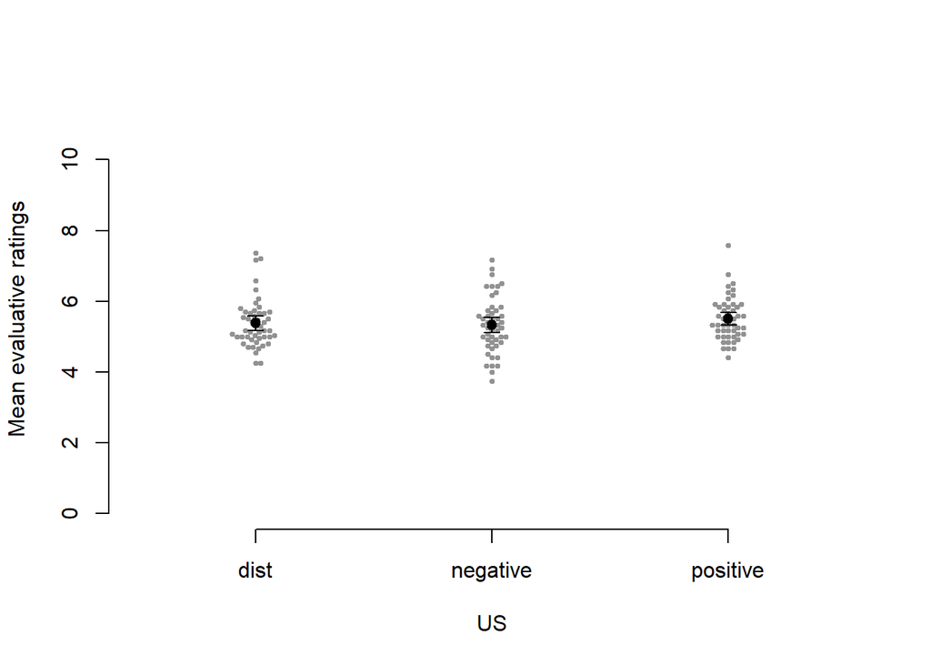

```r
dat_ev$`US Valence` = dat_ev$us_valence

#visualize the data
apa_beeplot(data=dat_ev, id="url.srid", dv="eval_rating", factors=c("US Valence"), use = "all.obs", ylim=c(0,11),
            xlab = "US"
            ,ylab = "Mean evaluative ratings")
```

# Recognition memory

```r
####
#RECOGNITION MEMORY
####

#compute recognition memory performance by computing freq("old"|old) (hits) and freq("old"|new) (fa)
dat = dat %>% mutate(reco_resp_bin = ifelse(reco_resp=="old", 1, 0))

dat_reco_agg = dat %>%
  group_by(url.srid, cs_exposure) %>%
  summarise(prop_old = mean(reco_resp_bin))

knitr::kable(dat_reco_agg, format = "html")
```

| url.srid | cs_exposure | prop_old |
| --- | --- | --- |
| 9866 | new | 0.0416667 |
| 9866 | old | 0.7083333 |
| 9867 | new | 0.0416667 |
| 9867 | old | 0.5416667 |
| 9868 | new | 0.0000000 |
| 9868 | old | 0.5416667 |
| 9869 | new | 0.0833333 |
| 9869 | old | 0.7083333 |
| 9870 | new | 0.0416667 |
| 9870 | old | 0.4583333 |
| 9871 | new | 0.2500000 |
| 9871 | old | 0.6250000 |
| 9872 | new | 0.0416667 |
| 9872 | old | 0.5833333 |
| 9873 | new | 0.0833333 |
| 9873 | old | 0.5000000 |
| 9874 | new | 0.0000000 |
| 9874 | old | 0.7083333 |
| 9875 | new | 0.0833333 |
| 9875 | old | 0.5000000 |
| 9876 | new | 0.0000000 |
| 9876 | old | 0.7083333 |
| 9877 | new | 0.0416667 |
| 9877 | old | 0.2916667 |
| 9879 | new | 0.0833333 |
| 9879 | old | 0.7083333 |
| 9880 | new | 0.2083333 |
| 9880 | old | 0.6666667 |
| 9881 | new | 0.0000000 |
| 9881 | old | 0.5833333 |

[output cut: 68 more lines]

```r
dat_reco_wide = dat_reco_agg %>% pivot_wider(names_from = "cs_exposure"
                                                 ,values_from = "prop_old")

dat_reco_wide$reco_corrected = dat_reco_wide$old - dat_reco_wide$new

describeBy(dat_reco_agg$prop_old, dat_reco_agg$cs_exposure)
```

```
 Descriptive statistics by group
group: new
   vars  n mean   sd median trimmed  mad min  max range skew kurtosis   se
X1    1 49 0.08 0.07   0.08    0.07 0.06   0 0.25  0.25 0.71    -0.57 0.01
------------------------------------------------------------
group: old
   vars  n mean   sd median trimmed  mad  min  max range skew kurtosis   se
X1    1 49 0.54 0.14   0.54    0.53 0.12 0.29 0.96  0.67  0.5     0.58 0.02
```

```r
describe(dat_reco_wide$reco_corrected)
```

```
   vars  n mean   sd median trimmed  mad  min  max range skew kurtosis   se
X1    1 49 0.46 0.17   0.46    0.45 0.12 0.08 0.96  0.88 0.38     0.41 0.02
```

```r
#by us valence

dat_reco_agg_val = dat %>%
  group_by(url.srid, us_valence) %>%
  summarise(prop_old = mean(reco_resp_bin))

knitr::kable(dat_reco_agg_val, format = "html")
```

| url.srid | us_valence | prop_old |
| --- | --- | --- |
| 9866 | dist | 0.0416667 |
| 9866 | negative | 0.5833333 |
| 9866 | positive | 0.8333333 |
| 9867 | dist | 0.0416667 |
| 9867 | negative | 0.4166667 |
| 9867 | positive | 0.6666667 |
| 9868 | dist | 0.0000000 |
| 9868 | negative | 0.2500000 |
| 9868 | positive | 0.8333333 |
| 9869 | dist | 0.0833333 |
| 9869 | negative | 0.8333333 |
| 9869 | positive | 0.5833333 |
| 9870 | dist | 0.0416667 |
| 9870 | negative | 0.3333333 |
| 9870 | positive | 0.5833333 |
| 9871 | dist | 0.2500000 |
| 9871 | negative | 0.6666667 |
| 9871 | positive | 0.5833333 |
| 9872 | dist | 0.0416667 |
| 9872 | negative | 0.6666667 |
| 9872 | positive | 0.5000000 |
| 9873 | dist | 0.0833333 |
| 9873 | negative | 0.5833333 |
| 9873 | positive | 0.4166667 |
| 9874 | dist | 0.0000000 |
| 9874 | negative | 0.6666667 |
| 9874 | positive | 0.7500000 |
| 9875 | dist | 0.0833333 |
| 9875 | negative | 0.5000000 |
| 9875 | positive | 0.5000000 |

[output cut: 117 more lines]

```r
dat_reco_wide_val = dat_reco_agg_val %>% pivot_wider(names_from = "us_valence"
                                                 ,values_from = "prop_old")

dat_reco_wide_val$reco_corrected_pos = dat_reco_wide_val$positive - dat_reco_wide_val$dist
dat_reco_wide_val$reco_corrected_neg = dat_reco_wide_val$negative - dat_reco_wide_val$dist

describeBy(dat_reco_agg_val$prop_old, dat_reco_agg_val$us_valence)
```

```
 Descriptive statistics by group
group: dist
   vars  n mean   sd median trimmed  mad min  max range skew kurtosis   se
X1    1 49 0.08 0.07   0.08    0.07 0.06   0 0.25  0.25 0.71    -0.57 0.01
------------------------------------------------------------
group: negative
   vars  n mean   sd median trimmed  mad  min  max range skew kurtosis   se
X1    1 49 0.52 0.17    0.5    0.51 0.12 0.17 0.92  0.75 0.35    -0.26 0.02
------------------------------------------------------------
group: positive
   vars  n mean   sd median trimmed  mad  min max range skew kurtosis   se
X1    1 49 0.56 0.18   0.58    0.56 0.12 0.25   1  0.75 0.28    -0.55 0.03
```

```r
describe(dat_reco_wide_val$reco_corrected_pos)
```

```
   vars  n mean  sd median trimmed  mad  min max range skew kurtosis   se
X1    1 49 0.48 0.2   0.46    0.47 0.19 0.08   1  0.92 0.47    -0.31 0.03
```

```r
describe(dat_reco_wide_val$reco_corrected_neg)
```

```
   vars  n mean  sd median trimmed  mad   min  max range skew kurtosis   se
X1    1 49 0.44 0.2   0.42    0.43 0.25 -0.04 0.92  0.96 0.17    -0.16 0.03
```

# CS-US pairing memory

```r
#Valence

dat = dat %>% mutate(val_us_accuracy_bin = ifelse(val_us_accuracy=="val_correct", 1, 0))

dat_source_mem = dat %>% filter(us_valence != "dist" & reco_accuracy == "hit") %>%
  group_by(url.srid, us_valence) %>%
  summarise(prop_correct_source = mean(val_us_accuracy_bin))

knitr::kable(dat_source_mem, format = "html")
```

| url.srid | us_valence | prop_correct_source |
| --- | --- | --- |
| 9866 | negative | 1.0000000 |
| 9866 | positive | 0.9000000 |
| 9867 | negative | 0.8000000 |
| 9867 | positive | 0.7500000 |
| 9868 | negative | 1.0000000 |
| 9868 | positive | 0.7000000 |
| 9869 | negative | 1.0000000 |
| 9869 | positive | 0.8571429 |
| 9870 | negative | 1.0000000 |
| 9870 | positive | 0.8571429 |
| 9871 | negative | 0.6250000 |
| 9871 | positive | 0.7142857 |
| 9872 | negative | 0.5000000 |
| 9872 | positive | 0.5000000 |
| 9873 | negative | 1.0000000 |
| 9873 | positive | 1.0000000 |
| 9874 | negative | 1.0000000 |
| 9874 | positive | 1.0000000 |
| 9875 | negative | 0.6666667 |
| 9875 | positive | 0.8333333 |
| 9876 | negative | 1.0000000 |
| 9876 | positive | 0.9000000 |
| 9877 | negative | 0.3333333 |
| 9877 | positive | 0.5000000 |
| 9879 | negative | 0.6666667 |
| 9879 | positive | 0.3750000 |
| 9880 | negative | 0.8333333 |
| 9880 | positive | 0.7000000 |
| 9881 | negative | 0.8333333 |
| 9881 | positive | 0.8750000 |

[output cut: 68 more lines]

```r
dat_source_mem_wide = dat_source_mem %>% pivot_wider(names_from = "us_valence"
                                                 ,values_from = "prop_correct_source")

dat_reco_agg_val_old = dat_reco_agg_val %>% filter(us_valence != "dist")
dat_reco_source = full_join(dat_reco_agg_val_old, dat_source_mem,
                               by = c("url.srid"="url.srid", "us_valence"="us_valence"))

describeBy(dat_reco_source$prop_correct_source, dat_reco_source$us_valence)
```

```
 Descriptive statistics by group
group: dist
NULL
------------------------------------------------------------
group: negative
   vars  n mean   sd median trimmed  mad  min max range  skew kurtosis   se
X1    1 49 0.85 0.17   0.86    0.87 0.21 0.33   1  0.67 -0.86    -0.12 0.02
------------------------------------------------------------
group: positive
   vars  n mean   sd median trimmed  mad min max range  skew kurtosis   se
X1    1 49 0.78 0.21   0.83    0.81 0.25 0.2   1   0.8 -1.04      0.4 0.03
```

```r
#Identity
dat = dat %>% mutate(id_us_accuracy_bin = ifelse(id_us_accuracy=="id_correct", 1, 0))

dat_id_mem = dat %>% filter(us_valence != "dist" & reco_accuracy == "hit") %>%
  group_by(url.srid, us_valence) %>%
  summarise(prop_correct_id = mean(id_us_accuracy_bin))

knitr::kable(dat_id_mem, format = "html")
```

| url.srid | us_valence | prop_correct_id |
| --- | --- | --- |
| 9866 | negative | 1.0000000 |
| 9866 | positive | 0.9000000 |
| 9867 | negative | 0.8000000 |
| 9867 | positive | 0.7500000 |
| 9868 | negative | 0.3333333 |
| 9868 | positive | 0.3000000 |
| 9869 | negative | 1.0000000 |
| 9869 | positive | 0.5714286 |
| 9870 | negative | 1.0000000 |
| 9870 | positive | 0.8571429 |
| 9871 | negative | 0.3750000 |
| 9871 | positive | 0.4285714 |
| 9872 | negative | 0.5000000 |
| 9872 | positive | 0.5000000 |
| 9873 | negative | 1.0000000 |
| 9873 | positive | 1.0000000 |
| 9874 | negative | 1.0000000 |
| 9874 | positive | 1.0000000 |
| 9875 | negative | 0.1666667 |
| 9875 | positive | 0.8333333 |
| 9876 | negative | 1.0000000 |
| 9876 | positive | 0.9000000 |
| 9877 | negative | 0.3333333 |
| 9877 | positive | 0.2500000 |
| 9879 | negative | 0.3333333 |
| 9879 | positive | 0.1250000 |
| 9880 | negative | 0.6666667 |
| 9880 | positive | 0.6000000 |
| 9881 | negative | 0.5000000 |
| 9881 | positive | 0.3750000 |

[output cut: 68 more lines]

```r
dat_id_mem_wide = dat_id_mem %>% pivot_wider(names_from = "us_valence"
                                                 ,values_from = "prop_correct_id")

dat_mem = full_join(dat_reco_source, dat_id_mem,
                               by = c("url.srid"="url.srid", "us_valence"="us_valence"))

describeBy(dat_mem$prop_correct_id, dat_mem$us_valence)
```

```
 Descriptive statistics by group
group: dist
NULL
------------------------------------------------------------
group: negative
   vars  n mean   sd median trimmed  mad min max range  skew kurtosis   se
X1    1 49 0.63 0.28   0.64    0.65 0.29   0   1     1 -0.24    -1.04 0.04
------------------------------------------------------------
group: positive
   vars  n mean   sd median trimmed  mad min max range  skew kurtosis   se
X1    1 49 0.62 0.27   0.67    0.64 0.25   0   1     1 -0.49    -0.52 0.04
```

```r
knitr::kable(dat_mem, format = "html")
```

| url.srid | us_valence | prop_old | prop_correct_source | prop_correct_id |
| --- | --- | --- | --- | --- |
| 9866 | negative | 0.5833333 | 1.0000000 | 1.0000000 |
| 9866 | positive | 0.8333333 | 0.9000000 | 0.9000000 |
| 9867 | negative | 0.4166667 | 0.8000000 | 0.8000000 |
| 9867 | positive | 0.6666667 | 0.7500000 | 0.7500000 |
| 9868 | negative | 0.2500000 | 1.0000000 | 0.3333333 |
| 9868 | positive | 0.8333333 | 0.7000000 | 0.3000000 |
| 9869 | negative | 0.8333333 | 1.0000000 | 1.0000000 |
| 9869 | positive | 0.5833333 | 0.8571429 | 0.5714286 |
| 9870 | negative | 0.3333333 | 1.0000000 | 1.0000000 |
| 9870 | positive | 0.5833333 | 0.8571429 | 0.8571429 |
| 9871 | negative | 0.6666667 | 0.6250000 | 0.3750000 |
| 9871 | positive | 0.5833333 | 0.7142857 | 0.4285714 |
| 9872 | negative | 0.6666667 | 0.5000000 | 0.5000000 |
| 9872 | positive | 0.5000000 | 0.5000000 | 0.5000000 |
| 9873 | negative | 0.5833333 | 1.0000000 | 1.0000000 |
| 9873 | positive | 0.4166667 | 1.0000000 | 1.0000000 |
| 9874 | negative | 0.6666667 | 1.0000000 | 1.0000000 |
| 9874 | positive | 0.7500000 | 1.0000000 | 1.0000000 |
| 9875 | negative | 0.5000000 | 0.6666667 | 0.1666667 |
| 9875 | positive | 0.5000000 | 0.8333333 | 0.8333333 |
| 9876 | negative | 0.5833333 | 1.0000000 | 1.0000000 |
| 9876 | positive | 0.8333333 | 0.9000000 | 0.9000000 |
| 9877 | negative | 0.2500000 | 0.3333333 | 0.3333333 |
| 9877 | positive | 0.3333333 | 0.5000000 | 0.2500000 |
| 9879 | negative | 0.7500000 | 0.6666667 | 0.3333333 |
| 9879 | positive | 0.6666667 | 0.3750000 | 0.1250000 |
| 9880 | negative | 0.5000000 | 0.8333333 | 0.6666667 |
| 9880 | positive | 0.8333333 | 0.7000000 | 0.6000000 |
| 9881 | negative | 0.5000000 | 0.8333333 | 0.5000000 |
| 9881 | positive | 0.6666667 | 0.8750000 | 0.3750000 |

[output cut: 68 more lines]

# Response frequencies + MPT model

```r
#compute response frequencies for MPT analyses

#First, remove NA in source memory responses and in the column storing the correct us
dat = dat %>% mutate(correct_us_source = replace_na(correct_us_source, "zz")
                     ,source_mem_resp = replace_na(source_mem_resp, "zz"))

##Create three datasets, one for each tree; them, we will merge them

##Tree: US+ and select only relevant columns
dat_pos = dat %>% filter(us_valence == "positive") %>% select(url.srid, cs, us_valence, correct_us_source, source_mem_resp)

#we compute responses as follows:
##if response == "zz", this means ppts provided a "new" response -- this is a "PosUSnew" as we are in the US+ tree
##then, if US identity response correct, response is "PosUSposcor"
##last, if US valence (in the absence of correct US identity response) is correct, "PosUSposincor" if valence is correct; else, "PosUSnegincor"
dat_pos = dat_pos %>% mutate(resp_mpt = ifelse(source_mem_resp == "zz"
                                               ,"PosUSnew"
                                               ,ifelse(source_mem_resp == correct_us_source
                                                       ,"PosUSposcor"
                                                       ,ifelse(substr(source_mem_resp, 0, 1)==substr(correct_us_source, 0, 1)
                                                              , "PosUSposincor"
                                                              , "PosUSnegincor"
                                                       )
                                               )
)
)

# /!\/!\/!\
# #ONLY run this code for TESTS
# we dont have "posUSposincor" in the test data, so I fake one "PosUSposincor" response
# a = which(dat_pos$resp_mpt=="PosUSposcor")
# dat_pos$resp_mpt[a[2]] = "PosUSposincor"
# //!\/!\

##Tree: US- and select only relevant columns
dat_neg = dat %>% filter(us_valence == "negative") %>% select(url.srid, cs, us_valence, correct_us_source, source_mem_resp)

#we compute responses as follows:
##if response == "zz", this means ppts provided a "new" response -- this is a "NegUSnew" as we are in the US- tree
##then, if US identity response correct, response is "NegUSnegcor"
##last, if US valence (in the absence of correct US identity response) is correct, "NegUSnegincor" if valence is correct; else, "NegUSposincor"
dat_neg = dat_neg %>% mutate(resp_mpt = ifelse(source_mem_resp == "zz"
                                               ,"NegUSnew"
                                               ,ifelse(source_mem_resp == correct_us_source
                                                       ,"NegUSnegcor"
                                                       ,ifelse(substr(source_mem_resp, 0, 1)==substr(correct_us_source, 0, 1)
                                                              , "NegUSnegincor"
                                                              , "NegUSposincor"
                                                       )
                                               )
)
)

#Tree: New and select only relevant columns
dat_new = dat %>% filter(us_valence == "dist") %>% select(url.srid, cs, us_valence, correct_us_source, source_mem_resp)

#we compute responses as follows:
##if response == "zz", this means ppts provided a "new" response -- this is a "Newnew" as we are in the New CS tree
##then, US memory responses are necessarily incorrect as no US was displayed
##if the selected US is positive, response is "Newposincor"
##if the selected US is negative, response is "Newnegincor"
dat_new = dat_new %>% mutate(resp_mpt = ifelse(source_mem_resp == "zz"
                                               ,"Newnew"
                                               ,ifelse(substr(source_mem_resp, 0, 1)=="p"
                                                              , "Newposincor"
                                                              , "Newnegincor")
)
)

#Merge datasets so that all responses are available into a single dataframe
##proceed in two stets: CS-US+ and CS-US- trees
dat_mpt.1 = full_join(dat_pos, dat_neg
                    ,by = c("url.srid"="url.srid", "cs"="cs", "us_valence"="us_valence", "correct_us_source"="correct_us_source","source_mem_resp"="source_mem_resp", "resp_mpt"="resp_mpt"))

#add new CS tree
dat_mpt = full_join(dat_mpt.1, dat_new
                    ,by = c("url.srid"="url.srid", "cs"="cs", "us_valence"="us_valence", "correct_us_source"="correct_us_source","source_mem_resp"="source_mem_resp", "resp_mpt"="resp_mpt"))
```

```r
#participants frequencies for each response type, even if 0 responses for a given participant
dat_mpt_freq = dat_mpt %>% #in dat_mpt
  group_by(url.srid, resp_mpt, .drop=FALSE) %>% #group observations by participant (url.srid) and resp_mpt (already capturing the tree)
  tally %>%
  spread(resp_mpt, n, fill=0) #use a "wide" format

dat_mpt_freq_fit = dat_mpt_freq %>% ungroup() %>% select(-url.srid)

#aggregated level if needed
dat_mpt_freq_agg = dat_mpt %>% #in dat_mpt
  group_by(resp_mpt, .drop=FALSE) %>% #group observations by resp_mpt (already capturing the tree)
  tally
```

```r
#we'll use this model
MPTinR::check.mpt("KW_wsw_model.eqn")
```

```
$probabilities.eq.1
[1] TRUE

$n.trees
[1] 3

$n.model.categories
[1] 11

$n.independent.categories
[1] 8

$n.params
[1] 10

$parameters
 [1] "a"    "b"    "Cneg" "Cpos" "Dn"   "dneg" "Dneg" "dpos" "Dpos" "G"

$eqn.order.trees
[1] "NegUS" "New"   "PosUS"

$eqn.order.categories
 [1] "NegUSnegcor"   "NegUSnegincor" "NegUSnew"      "NegUSposincor"
 [5] "Newnegincor"   "Newnew"        "Newposincor"   "PosUSnegincor"
 [9] "PosUSnew"      "PosUSposcor"   "PosUSposincor"
```

```r
#Fit the model and estimate parameters
# mod_mpt = traitMPT(
#   eqnfile = "KW_wsw_model.eqn"
#   , data = dat_mpt_freq %>% ungroup() %>% select(-url.srid)
#   , n.iter   = 400000
#   , n.adapt  =  20000
#   , n.burnin = 200000
#   , n.thin   = 40
#   , n.chains = 4
#   , restrictions = list("Dn=Dpos=Dneg","G=0.25")
# )
#
# save(mod_mpt, file ="fit_MPT.RData")
load("fit_MPT.RData")

summary(mod_mpt)
```

```
Call:
traitMPT(eqnfile = "KW_wsw_model.eqn", data = dat_mpt_freq %>%
    ungroup() %>% select(-url.srid), restrictions = list("Dn=Dpos=Dneg",
    "G=0.25"), n.iter = 4e+05, n.adapt = 20000, n.burnin = 2e+05,
    n.thin = 40, n.chains = 4)

Group-level medians of MPT parameters (probability scale):
           Mean    SD  2.5%   50% 97.5% Time-series SE n.eff  Rhat R_95%
mean_a    0.445 0.040 0.368 0.444 0.525          0.000  7286 1.000 1.001
mean_b    0.135 0.018 0.099 0.135 0.171          0.000  7142 1.001 1.004
mean_Cneg 0.744 0.087 0.567 0.745 0.911          0.001  5367 1.000 1.001
mean_Cpos 0.765 0.085 0.603 0.762 0.935          0.001  5157 1.001 1.003
mean_Dn   0.449 0.029 0.391 0.449 0.506          0.000  5541 1.001 1.003
mean_dneg 0.292 0.227 0.010 0.241 0.840          0.003  6364 1.001 1.002
mean_dpos 0.237 0.188 0.008 0.196 0.727          0.002  7436 1.001 1.002

Mean/Median of latent-trait values (probit-scale) across individuals:
                 Mean    SD   2.5%    50%  97.5% Time-series SE n.eff  Rhat
latent_mu_a    -0.139 0.103 -0.337 -0.140  0.063          0.001  7287 1.000
latent_mu_b    -1.108 0.086 -1.288 -1.103 -0.950          0.001  7150 1.001
latent_mu_Cneg  0.683 0.294  0.168  0.660  1.350          0.004  5797 1.000
latent_mu_Cpos  0.757 0.316  0.262  0.713  1.512          0.004  5188 1.001
latent_mu_Dn   -0.129 0.074 -0.278 -0.128  0.015          0.001  5533 1.001
latent_mu_dneg -0.703 0.833 -2.333 -0.705  0.994          0.010  6679 1.001
latent_mu_dpos -0.881 0.738 -2.400 -0.856  0.605          0.008  8715 1.001
               R_95%
latent_mu_a    1.001
latent_mu_b    1.004
latent_mu_Cneg 1.001
latent_mu_Cpos 1.003
latent_mu_Dn   1.003
latent_mu_dneg 1.002
latent_mu_dpos 1.002

Standard deviation of latent-trait values (probit scale) across individuals:
                   Mean    SD  2.5%   50% 97.5% Time-series SE n.eff  Rhat
latent_sigma_a    0.176 0.118 0.008 0.160 0.440          0.001  6258 1.003
latent_sigma_b    0.344 0.103 0.151 0.339 0.562          0.002  3851 1.000
latent_sigma_Cneg 1.328 0.506 0.639 1.239 2.564          0.005 12444 1.001
latent_sigma_Cpos 1.221 0.451 0.598 1.143 2.355          0.005  8144 1.000
```

[output cut: 57 more lines]

```

Correlations (posterior mean estimates) in matrix form:
          a      b   Cneg   Cpos     Dn   dneg   dpos
a     1.000 -0.147  0.239  0.128  0.232  0.174 -0.046
b    -0.147  1.000 -0.300 -0.078 -0.385 -0.086  0.103
Cneg  0.239 -0.300  1.000  0.540  0.231  0.265  0.060
Cpos  0.128 -0.078  0.540  1.000  0.060  0.221  0.156
Dn    0.232 -0.385  0.231  0.060  1.000  0.095 -0.087
dneg  0.174 -0.086  0.265  0.221  0.095  1.000  0.015
dpos -0.046  0.103  0.060  0.156 -0.087  0.015  1.000


##############
 Model fit statistics (posterior predictive p-values):
Use PPP(fittedModel) to get T1 and T2 posterior predictive checks.
```

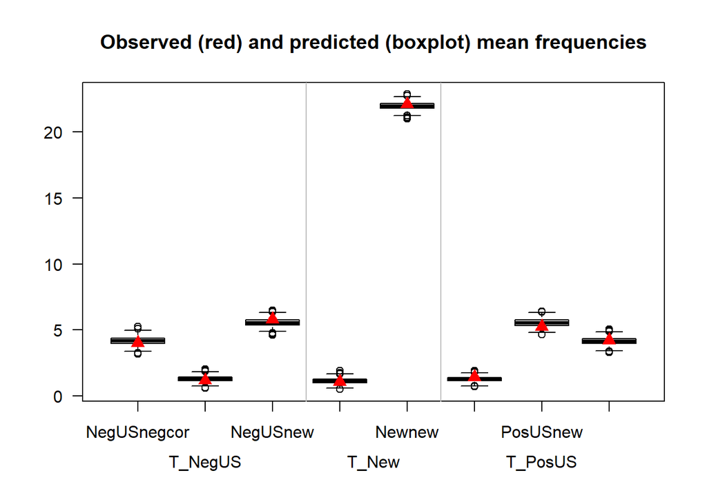

```r
TreeBUGS::plotFit(mod_mpt)
```

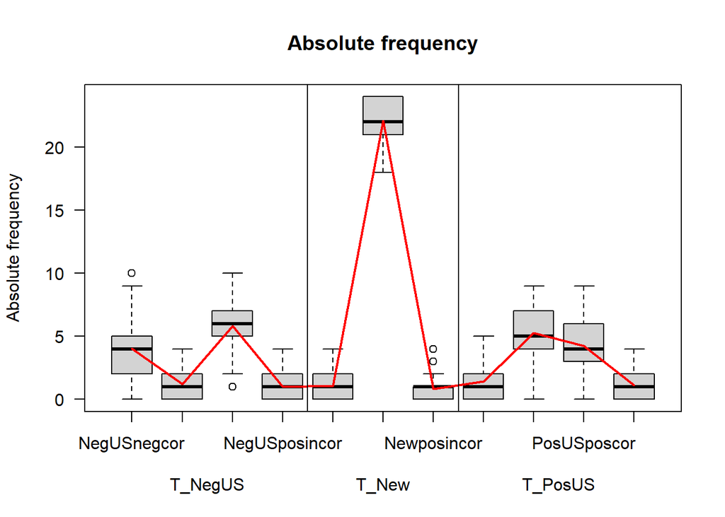

```r
TreeBUGS::plotFreq(mod_mpt)
```

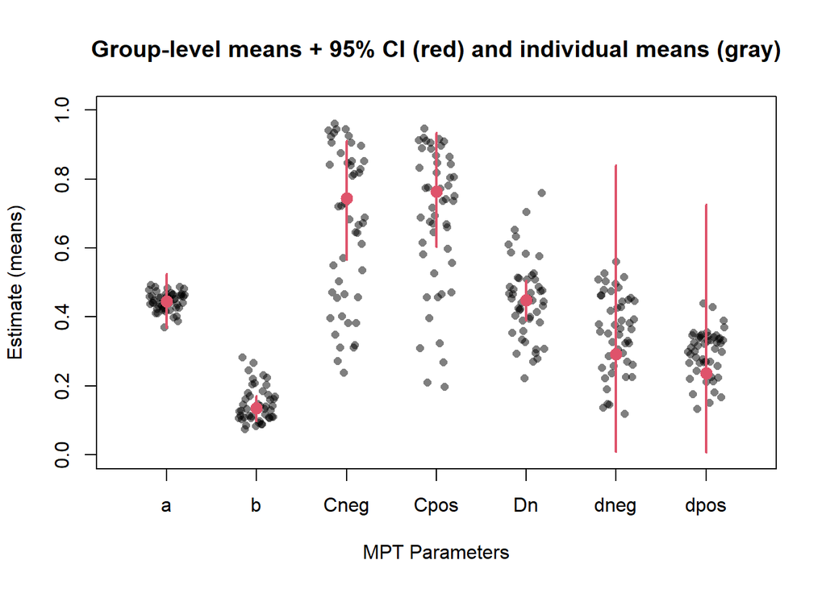

```r
TreeBUGS::plotParam(mod_mpt)
```

```r
mod_mpt_ppp = PPP(mod_mpt, M = 5e3)
mod_mpt_ppp
```

```
 ## Mean structure (T1):
 Observed =  0.1910721 ; Predicted =  0.1534554 ; p-value =  0.3444

## Covariance structure (T2):
 Observed =  5.500427 ; Predicted =  6.951666 ; p-value =  0.6934

## Individual fit (T1):
    1     2     3     4     5     6     7     8     9    10    11    12    13
0.468 0.389 0.092 0.198 0.613 0.623 0.139 0.459 0.802 0.613 0.531 0.556 0.476
   14    15    16    17    18    19    20    21    22    23    24    25    26
0.403 0.487 0.356 0.713 0.574 0.758 0.685 0.183 0.326 0.729 0.531 0.171 0.431
   27    28    29    30    31    32    33    34    35    36    37    38    39
0.585 0.776 0.487 0.672 0.525 0.504 0.308 0.255 0.580 0.497 0.846 0.563 0.617
   40    41    42    43    44    45    46    47    48    49
0.540 0.365 0.328 0.788 0.741 0.350 0.658 0.463 0.511 0.144
```

# Correlations between MPT parameters and CS ratings

```r
individual_parameters <- as.data.frame(getParam(mod_mpt, parameter = "theta"))
individual_parameters$id <- 1:nrow(individual_parameters)
agg_data <- aggregate(eval_rating ~ us_valence + url.srid, data = dat_ev, FUN = mean)
library(reshape2)
agg_data_d <- dcast(agg_data, value.var = "eval_rating", url.srid ~ us_valence)
agg_data_d$id <- 1:nrow(agg_data_d)

para_ratings <- merge(agg_data_d, individual_parameters, by = "id")

#para_ratings <- subset(para_ratings, url.srid %in% c("9860","9862","9864"))

cor.test(para_ratings$Dn,para_ratings$dist)
```

```
    Pearson's product-moment correlation

data:  para_ratings$Dn and para_ratings$dist
t = 0.69966, df = 47, p-value = 0.4876
alternative hypothesis: true correlation is not equal to 0
95 percent confidence interval:
 -0.1849487  0.3721014
sample estimates:
      cor
0.1015281
```

```r
cor.test(para_ratings$Dn,para_ratings$positive)
```

```
    Pearson's product-moment correlation

data:  para_ratings$Dn and para_ratings$positive
t = 0.48283, df = 47, p-value = 0.6315
alternative hypothesis: true correlation is not equal to 0
95 percent confidence interval:
 -0.2151940  0.3446419
sample estimates:
       cor
0.07025374
```

```r
cor.test(para_ratings$Dn,para_ratings$negative)
```

```
    Pearson's product-moment correlation

data:  para_ratings$Dn and para_ratings$negative
t = 0.73778, df = 47, p-value = 0.4643
alternative hypothesis: true correlation is not equal to 0
95 percent confidence interval:
 -0.1796021  0.3768561
sample estimates:
      cor
0.1069982
```

```r
cor.test(para_ratings$a,para_ratings$dist)
```

```
    Pearson's product-moment correlation

data:  para_ratings$a and para_ratings$dist
t = 0.76679, df = 47, p-value = 0.447
alternative hypothesis: true correlation is not equal to 0
95 percent confidence interval:
 -0.1755278  0.3804599
sample estimates:
      cor
0.1111551
```

```r
cor.test(para_ratings$a,para_ratings$positive)
```

```
    Pearson's product-moment correlation

data:  para_ratings$a and para_ratings$positive
t = 0.41055, df = 47, p-value = 0.6833
alternative hypothesis: true correlation is not equal to 0
95 percent confidence interval:
 -0.2252041  0.3353378
sample estimates:
       cor
0.05977801
```

```r
cor.test(para_ratings$a,para_ratings$negative)
```

```
    Pearson's product-moment correlation

data:  para_ratings$a and para_ratings$negative
t = 0.93555, df = 47, p-value = 0.3543
alternative hypothesis: true correlation is not equal to 0
95 percent confidence interval:
 -0.1517550  0.4011557
sample estimates:
      cor
0.1352115
```

```r
cor.test(para_ratings$b,para_ratings$dist)
```

```
    Pearson's product-moment correlation

data:  para_ratings$b and para_ratings$dist
t = 0.95546, df = 47, p-value = 0.3442
alternative hypothesis: true correlation is not equal to 0
95 percent confidence interval:
 -0.1489433  0.4035667
sample estimates:
      cor
0.1380345
```

```r
cor.test(para_ratings$b,para_ratings$positive)
```

```
    Pearson's product-moment correlation

data:  para_ratings$b and para_ratings$positive
t = 0.39324, df = 47, p-value = 0.6959
alternative hypothesis: true correlation is not equal to 0
95 percent confidence interval:
 -0.2275954  0.3330988
sample estimates:
       cor
0.05726617
```

```r
cor.test(para_ratings$b,para_ratings$negative)
```

```
    Pearson's product-moment correlation

data:  para_ratings$b and para_ratings$negative
t = 0.30816, df = 47, p-value = 0.7593
alternative hypothesis: true correlation is not equal to 0
95 percent confidence interval:
 -0.2393143  0.3220344
sample estimates:
       cor
0.04490406
```

```r
cor.test(para_ratings$Cneg,para_ratings$dist)
```

```
    Pearson's product-moment correlation

data:  para_ratings$Cneg and para_ratings$dist
t = 0.55354, df = 47, p-value = 0.5825
alternative hypothesis: true correlation is not equal to 0
95 percent confidence interval:
 -0.2053637  0.3536731
sample estimates:
       cor
0.08048043
```

```r
cor.test(para_ratings$Cneg,para_ratings$positive)
```

```
    Pearson's product-moment correlation

data:  para_ratings$Cneg and para_ratings$positive
t = 1.6325, df = 47, p-value = 0.1093
alternative hypothesis: true correlation is not equal to 0
95 percent confidence interval:
 -0.05300454  0.48147881
sample estimates:
      cor
0.2316446
```

```r
cor.test(para_ratings$Cneg,para_ratings$negative)
```

```
    Pearson's product-moment correlation

data:  para_ratings$Cneg and para_ratings$negative
t = 1.8551, df = 47, p-value = 0.06985
alternative hypothesis: true correlation is not equal to 0
95 percent confidence interval:
 -0.02157586  0.50528857
sample estimates:
      cor
0.2612055
```

```r
cor.test(para_ratings$Cpos,para_ratings$dist)
```

```
    Pearson's product-moment correlation

data:  para_ratings$Cpos and para_ratings$dist
t = 0.15127, df = 47, p-value = 0.8804
alternative hypothesis: true correlation is not equal to 0
95 percent confidence interval:
 -0.2607547  0.3013864
sample estimates:
       cor
0.02205932
```

```r
cor.test(para_ratings$Cpos,para_ratings$positive)
```

```
    Pearson's product-moment correlation

data:  para_ratings$Cpos and para_ratings$positive
t = 1.7221, df = 47, p-value = 0.09163
alternative hypothesis: true correlation is not equal to 0
95 percent confidence interval:
 -0.04033735  0.49117108
sample estimates:
      cor
0.2436226
```

```r
cor.test(para_ratings$Cpos,para_ratings$negative)
```

```
    Pearson's product-moment correlation

data:  para_ratings$Cpos and para_ratings$negative
t = 2.0387, df = 47, p-value = 0.04713
alternative hypothesis: true correlation is not equal to 0
95 percent confidence interval:
 0.00417202 0.52421466
sample estimates:
      cor
0.2850342
```

```r
cor.test(para_ratings$dpos,para_ratings$dist)
```

```
    Pearson's product-moment correlation

data:  para_ratings$dpos and para_ratings$dist
t = -0.17819, df = 47, p-value = 0.8593
alternative hypothesis: true correlation is not equal to 0
95 percent confidence interval:
 -0.3049520  0.2570915
sample estimates:
        cor
-0.02598355
```

```r
cor.test(para_ratings$dpos,para_ratings$positive)
```

```
    Pearson's product-moment correlation

data:  para_ratings$dpos and para_ratings$positive
t = 1.6198, df = 47, p-value = 0.112
alternative hypothesis: true correlation is not equal to 0
95 percent confidence interval:
 -0.05480114  0.48009348
sample estimates:
      cor
0.2299388
```

```r
cor.test(para_ratings$dpos,para_ratings$negative)
```

```
    Pearson's product-moment correlation

data:  para_ratings$dpos and para_ratings$negative
t = 0.76381, df = 47, p-value = 0.4488
alternative hypothesis: true correlation is not equal to 0
95 percent confidence interval:
 -0.1759466  0.3800902
sample estimates:
      cor
0.1107283
```

```r
cor.test(para_ratings$dneg,para_ratings$dist)
```

```
    Pearson's product-moment correlation

data:  para_ratings$dneg and para_ratings$dist
t = 0.25509, df = 47, p-value = 0.7998
alternative hypothesis: true correlation is not equal to 0
95 percent confidence interval:
 -0.2465918  0.3150852
sample estimates:
       cor
0.03718304
```

```r
cor.test(para_ratings$dneg,para_ratings$positive)
```

```
    Pearson's product-moment correlation

data:  para_ratings$dneg and para_ratings$positive
t = 1.797, df = 47, p-value = 0.07877
alternative hypothesis: true correlation is not equal to 0
95 percent confidence interval:
 -0.02977035  0.49915694
sample estimates:
      cor
0.2535488
```

```r
cor.test(para_ratings$dneg,para_ratings$negative)
```

```
    Pearson's product-moment correlation

data:  para_ratings$dneg and para_ratings$negative
t = 1.5945, df = 47, p-value = 0.1175
alternative hypothesis: true correlation is not equal to 0
95 percent confidence interval:
 -0.05837936  0.47732640
sample estimates:
      cor
0.2265361
```

```r
dat_reco_wide_val$id <- 1:nrow(dat_reco_wide_val)

dat_reco_wide_val_param <- merge(dat_reco_wide_val, individual_parameters, by = "id")

cor.test(dat_reco_wide_val_param$reco_corrected_pos, dat_reco_wide_val_param$reco_corrected_pos)
```

```
    Pearson's product-moment correlation

data:  dat_reco_wide_val_param$reco_corrected_pos and dat_reco_wide_val_param$reco_corrected_pos
t = Inf, df = 47, p-value < 2.2e-16
alternative hypothesis: true correlation is not equal to 0
95 percent confidence interval:
 1 1
sample estimates:
cor
  1
```

```r
cor.test(dat_reco_wide_val_param$reco_corrected_neg, dat_reco_wide_val_param$reco_corrected_neg)
```

```
    Pearson's product-moment correlation

data:  dat_reco_wide_val_param$reco_corrected_neg and dat_reco_wide_val_param$reco_corrected_neg
t = Inf, df = 47, p-value < 2.2e-16
alternative hypothesis: true correlation is not equal to 0
95 percent confidence interval:
 1 1
sample estimates:
cor
  1
```

```r
dat_mem_pos = dat_mem %>% filter(us_valence=="positive")
dat_mem_neg = dat_mem %>% filter(us_valence=="negative")

dat_mem_pos$id <- 1:nrow(dat_mem_pos)
dat_mem_neg$id <- 1:nrow(dat_mem_neg)

dat_pos_m = full_join(dat_mem_pos, individual_parameters, by = c("id"="id"))
dat_neg_m = full_join(dat_mem_neg, individual_parameters, by = c("id"="id"))

cor.test(dat_pos_m$prop_correct_source, dat_pos_m$dpos)
```

```
    Pearson's product-moment correlation

data:  dat_pos_m$prop_correct_source and dat_pos_m$dpos
t = 7.2015, df = 47, p-value = 4.047e-09
alternative hypothesis: true correlation is not equal to 0
95 percent confidence interval:
 0.5564101 0.8353488
sample estimates:
      cor
0.7242847
```

```r
cor.test(dat_neg_m$prop_correct_source, dat_neg_m$dneg)
```

```
    Pearson's product-moment correlation

data:  dat_neg_m$prop_correct_source and dat_neg_m$dneg
t = 10.275, df = 47, p-value = 1.324e-13
alternative hypothesis: true correlation is not equal to 0
95 percent confidence interval:
 0.7187733 0.9020405
sample estimates:
     cor
0.831841
```

```r
cor.test(dat_pos_m$prop_correct_id, dat_pos_m$Cpos)
```

```
    Pearson's product-moment correlation

data:  dat_pos_m$prop_correct_id and dat_pos_m$Cpos
t = 18.865, df = 47, p-value < 2.2e-16
alternative hypothesis: true correlation is not equal to 0
95 percent confidence interval:
 0.8952726 0.9658085
sample estimates:
      cor
0.9398613
```

```r
cor.test(dat_neg_m$prop_correct_id, dat_neg_m$Cneg)
```

```
    Pearson's product-moment correlation

data:  dat_neg_m$prop_correct_id and dat_neg_m$Cneg
t = 24.317, df = 47, p-value < 2.2e-16
alternative hypothesis: true correlation is not equal to 0
95 percent confidence interval:
 0.9340909 0.9787747
sample estimates:
      cor
0.9624795
```

# G statistics MPT analyses

```r
MPTinR::check.mpt("KW_wsw_model.eqn")
```

```
$probabilities.eq.1
[1] TRUE

$n.trees
[1] 3

$n.model.categories
[1] 11

$n.independent.categories
[1] 8

$n.params
[1] 10

$parameters
 [1] "a"    "b"    "Cneg" "Cpos" "Dn"   "dneg" "Dneg" "dpos" "Dpos" "G"

$eqn.order.trees
[1] "NegUS" "New"   "PosUS"

$eqn.order.categories
 [1] "NegUSnegcor"   "NegUSnegincor" "NegUSnew"      "NegUSposincor"
 [5] "Newnegincor"   "Newnew"        "Newposincor"   "PosUSnegincor"
 [9] "PosUSnew"      "PosUSposcor"   "PosUSposincor"
```

```r
#MPT on aggregated frequencies
mod_agg = fit.mpt(data = dat_mpt_freq_agg$n
        ,model.filename = "KW_wsw_model.eqn"
        ,restrictions.filename = list("Dn=Dpos=Dneg","G=0.25")
        )
```

```
[1] "Model fitting begins at 2023-02-28 13:01:38"
[1] "Model fitting stopped at 2023-02-28 13:01:39"
Time difference of 0.192956 secs
```

```r
mod_agg
```

```
$goodness.of.fit
  Log.Likelihood G.Squared df   p.value
1      -1773.253  2.684134  1 0.1013523

$information.criteria
       AIC      BIC
1 16.68413 57.02528

$model.info
  rank.fisher n.parameters n.independent.categories
1           7            7                        8

$parameters
     estimates lower.conf upper.conf restricted.parameter
a    0.4301075  0.3294858  0.5307292
b    0.1464567  0.1208804  0.1720329
Cneg 0.6871560  0.6079469  0.7663650
Cpos 0.6691536  0.5943185  0.7439887
Dn   0.4600340  0.4276375  0.4924305                 Dneg
dneg 0.1697843 -0.2875202  0.6270887
Dneg 0.4600340  0.4276375  0.4924305
dpos 0.2051424 -0.1253843  0.5356691
Dpos 0.4600340  0.4276375  0.4924305                 Dneg
G    0.2500000         NA         NA                 0.25

$data
$data$observed
     [,1] [,2] [,3] [,4] [,5] [,6] [,7] [,8] [,9] [,10] [,11]
[1,]  197   58  285   48   53 1083   40   70  257   207    54

$data$predicted
         [,1]     [,2] [,3]     [,4] [,5] [,6] [,7]     [,8] [,9]    [,10]
[1,] 206.1023 60.67987  271 50.21782   53 1083   40 67.03927  271 198.2447
        [,11]
[1,] 51.71601


$fitting.runs
          Min.   1st Qu.    Median      Mean   3rd Qu.      Max.
[1,] -1773.253 -1773.253 -1773.253 -1773.253 -1773.253 -1773.253
```

```r
#main model with dpos = 0
model_mpt_no_dpos = fit.mpt(data = dat_mpt_freq_agg$n
        ,model.filename = "KW_wsw_model.eqn"
                         ,restrictions.filename = list("Dn=Dpos=Dneg","G=0.25","dpos=0"))
```

```
[1] "Model fitting begins at 2023-02-28 13:01:39"
[1] "Model fitting stopped at 2023-02-28 13:01:39"
Time difference of 0.14059 secs
```

```r
model_mpt_no_dpos
```

```
$goodness.of.fit
  Log.Likelihood G.Squared df  p.value
1      -1773.879  3.935629  2 0.139762

$information.criteria
       AIC      BIC
1 15.93563 50.51376

$model.info
  rank.fisher n.parameters n.independent.categories
1           6            6                        8

$parameters
     estimates lower.conf upper.conf restricted.parameter
a    0.4735771  0.4064694  0.5406847
b    0.1464567  0.1208804  0.1720329
Cneg 0.6871560  0.6079469  0.7663650
Cpos 0.6739246  0.6001532  0.7476960
Dn   0.4600340  0.4276375  0.4924305                 Dneg
dneg 0.2964270 -0.0472534  0.6401074
Dneg 0.4600340  0.4276375  0.4924305
dpos 0.0000000         NA         NA                    0
Dpos 0.4600340  0.4276375  0.4924305                 Dneg
G    0.2500000         NA         NA                 0.25

$data
$data$observed
     [,1] [,2] [,3] [,4] [,5] [,6] [,7] [,8] [,9] [,10] [,11]
[1,]  197   58  285   48   53 1083   40   70  257   207    54

$data$predicted
         [,1]     [,2] [,3]     [,4]     [,5] [,6]     [,7]     [,8] [,9]
[1,] 206.1023 60.67987  271 50.21782 48.95733 1083 44.04267 70.91095  271
        [,10]    [,11]
[1,] 198.2447 47.84433


$fitting.runs
          Min.   1st Qu.    Median      Mean   3rd Qu.      Max.
[1,] -1773.879 -1773.879 -1773.879 -1773.879 -1773.879 -1773.879
```

```r
#main model with dneg = 0
model_mpt_no_dneg = fit.mpt(data = dat_mpt_freq_agg$n
        ,model.filename = "KW_wsw_model.eqn"
                         ,restrictions.filename = list("Dn=Dpos=Dneg","G=0.25","dneg=0"))
```

```
[1] "Model fitting begins at 2023-02-28 13:01:39"
[1] "Model fitting stopped at 2023-02-28 13:01:39"
Time difference of 0.1309052 secs
```

```r
model_mpt_no_dneg
```

```
$goodness.of.fit
  Log.Likelihood G.Squared df   p.value
1      -1773.486  3.149822  2 0.2070259

$information.criteria
       AIC      BIC
1 15.14982 49.72795

$model.info
  rank.fisher n.parameters n.independent.categories
1           6            6                        8

$parameters
     estimates  lower.conf upper.conf restricted.parameter
a    0.4045229  0.33696444  0.4720814
b    0.1464567  0.12088044  0.1720329
Cneg 0.6902235  0.61191008  0.7685369
Cpos 0.6691536  0.59431850  0.7439887
Dn   0.4600340  0.42763750  0.4924305                 Dneg
dneg 0.0000000          NA         NA                    0
Dneg 0.4600340  0.42763750  0.4924305
dpos 0.2616174 -0.00521363  0.5284484
Dpos 0.4600340  0.42763750  0.4924305                 Dneg
G    0.2500000          NA         NA                 0.25

$data
$data$observed
     [,1] [,2] [,3] [,4] [,5] [,6] [,7] [,8] [,9] [,10] [,11]
[1,]  197   58  285   48   53 1083   40   70  257   207    54

$data$predicted
         [,1]     [,2] [,3]     [,4]     [,5] [,6]     [,7]     [,8] [,9]
[1,] 206.1023 58.19056  271 52.70713 55.37937 1083 37.62063 67.03927  271
        [,10]    [,11]
[1,] 198.2447 51.71601


$fitting.runs
          Min.   1st Qu.    Median      Mean   3rd Qu.      Max.
[1,] -1773.486 -1773.486 -1773.486 -1773.486 -1773.486 -1773.486
```

```r
#main model with dpos = dneg
model_mpt_dpos_dneg = fit.mpt(data = dat_mpt_freq_agg$n
        ,model.filename = "KW_wsw_model.eqn"
                         ,restrictions.filename = list("Dn=Dpos=Dneg","G=0.25","dpos=dneg"))
```

```
[1] "Model fitting begins at 2023-02-28 13:01:39"
[1] "Model fitting stopped at 2023-02-28 13:01:39"
Time difference of 0.162482 secs
```

```r
model_mpt_dpos_dneg
```

```
$goodness.of.fit
  Log.Likelihood G.Squared df   p.value
1      -1773.258  2.694466  2 0.2599586

$information.criteria
       AIC      BIC
1 14.69447 49.27259

$model.info
  rank.fisher n.parameters n.independent.categories
1           6            6                        8

$parameters
     estimates   lower.conf upper.conf restricted.parameter
a    0.4343459  0.375446235  0.4932456
b    0.1464585  0.120881947  0.1720351
Cneg 0.6869346  0.607788515  0.7660807
Cpos 0.6693116  0.594575676  0.7440476
Dn   0.4600321  0.427635251  0.4924289                 Dneg
dneg 0.1910353 -0.001601148  0.3836717
Dneg 0.4600321  0.427635251  0.4924289
dpos 0.1910353 -0.001601148  0.3836717                 dneg
Dpos 0.4600321  0.427635251  0.4924289                 Dneg
G    0.2500000           NA         NA                 0.25

$data
$data$observed
     [,1] [,2] [,3] [,4] [,5] [,6] [,7] [,8] [,9] [,10] [,11]
[1,]  197   58  285   48   53 1083   40   70  257   207    54

$data$predicted
        [,1]     [,2]     [,3]     [,4]     [,5]     [,6]     [,7]     [,8]
[1,] 206.123 60.92383 271.0004 49.95282 52.60668 1082.998 40.39483 67.23552
         [,9]    [,10]    [,11]
[1,] 271.0004 198.2271 51.53705


$fitting.runs
          Min.   1st Qu.    Median      Mean   3rd Qu.      Max.
[1,] -1773.258 -1773.258 -1773.258 -1773.258 -1773.258 -1773.258
```

```r
#main model with Cpos = 0
model_mpt_no_Cpos = fit.mpt(data = dat_mpt_freq_agg$n
        ,model.filename = "KW_wsw_model.eqn"
                         ,restrictions.filename = list("Dn=Dpos=Dneg","G=0.25","Cpos=0"))
```

```
[1] "Model fitting begins at 2023-02-28 13:01:39"
[1] "Model fitting stopped at 2023-02-28 13:01:39"
Time difference of 0.1492629 secs
```

```r
model_mpt_no_Cpos
```

```
$goodness.of.fit
  Log.Likelihood G.Squared df      p.value
1      -1942.689  341.5559  2 6.793375e-75

$information.criteria
       AIC     BIC
1 353.5559 388.134

$model.info
  rank.fisher n.parameters n.independent.categories
1           6            6                        8

$parameters
     estimates lower.conf upper.conf restricted.parameter
a    0.4301075  0.3294858  0.5307292
b    0.1464567  0.1208804  0.1720329
Cneg 0.6871560  0.6079469  0.7663650
Cpos 0.0000000         NA         NA                    0
Dn   0.4600340  0.4276375  0.4924305                 Dneg
dneg 0.1697842 -0.2875202  0.6270887
Dneg 0.4600340  0.4276375  0.4924305
dpos 0.7370242  0.6156371  0.8584113
Dpos 0.4600340  0.4276375  0.4924305                 Dneg
G    0.2500000         NA         NA                 0.25

$data
$data$observed
     [,1] [,2] [,3] [,4] [,5] [,6] [,7] [,8] [,9] [,10] [,11]
[1,]  197   58  285   48   53 1083   40   70  257   207    54

$data$predicted
         [,1]     [,2] [,3]     [,4] [,5] [,6] [,7]     [,8] [,9]    [,10]
[1,] 206.1023 60.67987  271 50.21782   53 1083   40 67.03927  271 62.49018
        [,11]
[1,] 187.4705


$fitting.runs
          Min.   1st Qu.    Median      Mean   3rd Qu.      Max.
[1,] -1942.689 -1942.689 -1942.689 -1942.689 -1942.689 -1942.689
```

```r
#main model with Cneg = 0
model_mpt_no_Cneg = fit.mpt(data = dat_mpt_freq_agg$n
        ,model.filename = "KW_wsw_model.eqn"
                         ,restrictions.filename = list("Dn=Dpos=Dneg","G=0.25","Cneg=0"))
```

```
[1] "Model fitting begins at 2023-02-28 13:01:39"
[1] "Model fitting stopped at 2023-02-28 13:01:39"
Time difference of 0.1584671 secs
```

```r
model_mpt_no_Cneg
```

```
$goodness.of.fit
  Log.Likelihood G.Squared df      p.value
1      -1926.313  308.8045  2 8.789386e-68

$information.criteria
       AIC      BIC
1 320.8045 355.3826

$model.info
  rank.fisher n.parameters n.independent.categories
1           6            6                        8

$parameters
     estimates lower.conf upper.conf restricted.parameter
a    0.4301075  0.3294858  0.5307292
b    0.1464567  0.1208804  0.1720329
Cneg 0.0000000         NA         NA                    0
Cpos 0.6691536  0.5943185  0.7439887
Dn   0.4600340  0.4276375  0.4924305                 Dneg
dneg 0.7402720  0.5872818  0.8932622
Dneg 0.4600340  0.4276375  0.4924305
dpos 0.2051424 -0.1253843  0.5356691
Dpos 0.4600340  0.4276375  0.4924305                 Dneg
G    0.2500000         NA         NA                 0.25

$data
$data$observed
     [,1] [,2] [,3] [,4] [,5] [,6] [,7] [,8] [,9] [,10] [,11]
[1,]  197   58  285   48   53 1083   40   70  257   207    54

$data$predicted
         [,1]     [,2] [,3]     [,4] [,5] [,6] [,7]     [,8] [,9]    [,10]
[1,] 66.69554 200.0866  271 50.21782   53 1083   40 67.03927  271 198.2447
        [,11]
[1,] 51.71601


$fitting.runs
          Min.   1st Qu.    Median      Mean   3rd Qu.      Max.
[1,] -1926.313 -1926.313 -1926.313 -1926.313 -1926.313 -1926.313
```

```r
#main model with Cneg = 0
model_mpt_Cpos_Cneg = fit.mpt(data = dat_mpt_freq_agg$n
        ,model.filename = "KW_wsw_model.eqn"
                         ,restrictions.filename = list("Dn=Dpos=Dneg","G=0.25","Cneg=Cpos"))
```

```
[1] "Model fitting begins at 2023-02-28 13:01:39"
[1] "Model fitting stopped at 2023-02-28 13:01:40"
Time difference of 0.2514839 secs
```

```r
model_mpt_Cpos_Cneg
```

```
$goodness.of.fit
  Log.Likelihood G.Squared df   p.value
1      -1773.311  2.799665  2 0.2466383

$information.criteria
       AIC      BIC
1 14.79966 49.37779

$model.info
  rank.fisher n.parameters n.independent.categories
1           6            6                        8

$parameters
     estimates lower.conf upper.conf restricted.parameter
a    0.4301075  0.3294858  0.5307292
b    0.1464567  0.1208804  0.1720329
Cneg 0.6775348  0.6206394  0.7344302                 Cpos
Cpos 0.6775348  0.6206394  0.7344302
Dn   0.4600340  0.4276375  0.4924305                 Dneg
dneg 0.1750772 -0.2746567  0.6248110
Dneg 0.4600340  0.4276375  0.4924305
dpos 0.2019600 -0.1316977  0.5356177
Dpos 0.4600340  0.4276375  0.4924305                 Dneg
G    0.2500000         NA         NA                 0.25

$data
$data$observed
     [,1] [,2] [,3] [,4] [,5] [,6] [,7] [,8] [,9] [,10] [,11]
[1,]  197   58  285   48   53 1083   40   70  257   207    54

$data$predicted
         [,1]    [,2] [,3]     [,4] [,5] [,6] [,7]    [,8] [,9]    [,10]
[1,] 203.9677 62.0837  271 50.94856   53 1083   40 66.1705  271 200.1623
        [,11]
[1,] 50.66724


$fitting.runs
          Min.   1st Qu.    Median      Mean   3rd Qu.      Max.
[1,] -1773.311 -1773.311 -1773.311 -1773.311 -1773.311 -1773.311
```

```r
#main model with a = .5
model_mpt_a5 = fit.mpt(data = dat_mpt_freq_agg$n
        ,model.filename = "KW_wsw_model.eqn"
                         ,restrictions.filename = list("Dn=Dpos=Dneg","G=0.25","a=0.5"))
```

```
[1] "Model fitting begins at 2023-02-28 13:01:40"
[1] "Model fitting stopped at 2023-02-28 13:01:40"
Time difference of 0.136657 secs
```

```r
model_mpt_a5
```

```
$goodness.of.fit
  Log.Likelihood G.Squared df   p.value
1      -1774.165  4.507303  2 0.1050151

$information.criteria
      AIC      BIC
1 16.5073 51.08543

$model.info
  rank.fisher n.parameters n.independent.categories
1           6            6                        8

$parameters
      estimates  lower.conf upper.conf restricted.parameter
a    0.50000000          NA         NA                  0.5
b    0.14645669  0.12088044  0.1720329
Cneg 0.68715596  0.60794690  0.7663650
Cpos 0.66915358  0.59431850  0.7439887
Dn   0.46003401  0.42763750  0.4924305                 Dneg
dneg 0.36264600  0.08328938  0.6420026
Dneg 0.46003401  0.42763750  0.4924305
dpos 0.02140265 -0.24799256  0.2907979
Dpos 0.46003401  0.42763750  0.4924305                 Dneg
G    0.25000000          NA         NA                 0.25

$data
$data$observed
     [,1] [,2] [,3] [,4] [,5] [,6] [,7] [,8] [,9] [,10] [,11]
[1,]  197   58  285   48   53 1083   40   70  257   207    54

$data$predicted
         [,1]     [,2] [,3]     [,4] [,5] [,6] [,7]     [,8] [,9]    [,10]
[1,] 206.1023 60.67987  271 50.21782 46.5 1083 46.5 67.03927  271 198.2447
        [,11]
[1,] 51.71601


$fitting.runs
          Min.   1st Qu.    Median      Mean   3rd Qu.      Max.
[1,] -1774.165 -1774.165 -1774.165 -1774.165 -1774.165 -1774.165
```

```r
#test if nested models decrease model fit

#delta G^2 model_no_dpos - main_model
pchisq(q = model_mpt_no_dpos$goodness.of.fit[[2]] - mod_agg$goodness.of.fit[[2]]
       ,df = model_mpt_no_dpos$goodness.of.fit[[3]] - mod_agg$goodness.of.fit[[3]]
       ,lower.tail = FALSE)
```

```
[1] 0.2632672
```

```r
#no dpos does not decrease model fit

#delta G^2 model_no_dpos - main_model
pchisq(q = model_mpt_no_dneg$goodness.of.fit[[2]] - mod_agg$goodness.of.fit[[2]]
       ,df = model_mpt_no_dneg$goodness.of.fit[[3]] - mod_agg$goodness.of.fit[[3]]
       ,lower.tail = FALSE)
```

```
[1] 0.4949774
```

```r
#no dneg does not decrease model fit

#delta G^2 model_dpos_dneg - main_model
pchisq(q = model_mpt_dpos_dneg$goodness.of.fit[[2]] - mod_agg$goodness.of.fit[[2]]
       ,df = model_mpt_dpos_dneg$goodness.of.fit[[3]] - mod_agg$goodness.of.fit[[3]]
       ,lower.tail = FALSE)
```

```
[1] 0.9190373
```

```r
#dpos = dneg does not decrease model fit

#delta G^2 model_no_Cpos - main_model
pchisq(q = model_mpt_no_Cpos$goodness.of.fit[[2]] - mod_agg$goodness.of.fit[[2]]
       ,df = model_mpt_no_Cpos$goodness.of.fit[[3]] - mod_agg$goodness.of.fit[[3]]
       ,lower.tail = FALSE)
```

```
[1] 1.123539e-75
```

```r
#no Cpos decreases model fit

#delta G^2 model_no_Cneg - main_model
pchisq(q = model_mpt_no_Cneg$goodness.of.fit[[2]] - mod_agg$goodness.of.fit[[2]]
       ,df = model_mpt_no_Cneg$goodness.of.fit[[3]] - mod_agg$goodness.of.fit[[3]]
       ,lower.tail = FALSE)
```

```
[1] 1.528965e-68
```

```r
#no Cneg decreases model fit

#delta G^2 model_Cpos_Cneg - main_model
pchisq(q = model_mpt_Cpos_Cneg$goodness.of.fit[[2]] - mod_agg$goodness.of.fit[[2]]
       ,df = model_mpt_Cpos_Cneg$goodness.of.fit[[3]] - mod_agg$goodness.of.fit[[3]]
       ,lower.tail = FALSE)
```

```
[1] 0.7339334
```

```r
#Cpos = Cneg does not decrease model fit

#delta G^2 model_a5 - main_model
pchisq(q = model_mpt_a5$goodness.of.fit[[2]] - mod_agg$goodness.of.fit[[2]]
       ,df = model_mpt_a5$goodness.of.fit[[3]] - mod_agg$goodness.of.fit[[3]]
       ,lower.tail = FALSE)
```

```
[1] 0.1769365
```

```r
#a = .5 does not decrease model fit
```

# test regression models parameter estimates – evaluative ratings

```r
#scale predictors
para_ratings = para_ratings %>% mutate(
  Dn_scale = scale(Dn, center=TRUE, scale=FALSE)
  ,dneg_scale = scale(dneg, center=TRUE, scale=FALSE)
  ,dpos_scale = scale(dpos, center=TRUE, scale=FALSE)
  ,a_scale = scale(a, center=TRUE, scale=FALSE)
  ,b_scale = scale(b, center=TRUE, scale=FALSE)
  ,Cneg_scale = scale(Cneg, center=TRUE, scale=FALSE)
  ,Cpos_scale = scale(Cpos, center=TRUE, scale=FALSE)
  )

#new items
mod_new = lm(formula = dist~Dn_scale+b_scale+a_scale
                  ,data = para_ratings
                  )

summary(mod_new)
```

```
Call:
lm(formula = dist ~ Dn_scale + b_scale + a_scale, data = para_ratings)

Residuals:
    Min      1Q  Median      3Q     Max
-1.1271 -0.4587 -0.1177  0.3444  1.9328

Coefficients:
            Estimate Std. Error t value Pr(>|t|)
(Intercept)  5.37925    0.09714  55.379   <2e-16 ***
Dn_scale     1.02257    1.30025   0.786   0.4357
b_scale      4.28080    2.42358   1.766   0.0841 .
a_scale      3.89327    5.25859   0.740   0.4629
---
Signif. codes:  0 '***' 0.001 '**' 0.01 '*' 0.05 '.' 0.1 ' ' 1

Residual standard error: 0.68 on 45 degrees of freedom
Multiple R-squared:  0.07736,   Adjusted R-squared:  0.01585
F-statistic: 1.258 on 3 and 45 DF,  p-value: 0.3002
```

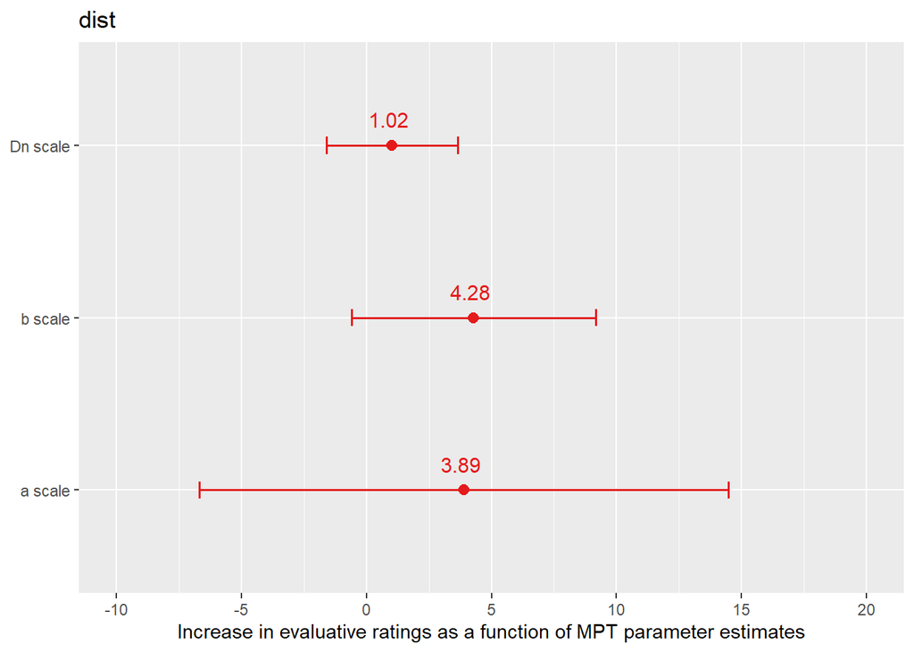

```r
sjPlot::plot_model(mod_new, show.values = TRUE, width = 0.1)+
  ylab("Increase in evaluative ratings as a function of MPT parameter estimates")
```

```r
sjPlot::tab_model(mod_new,
          show.intercept = F,
          p.style = "numeric_stars")
```

dist

Predictors

Estimates

CI

p

Dn scale

1.02

-1.60 – 3.64

0.436

b scale

4.28

-0.60 – 9.16

0.084

a scale

3.89

-6.70 – 14.48

0.463

Observations

49

R<sup>2</sup> / R<sup>2</sup> adjusted

0.077 / 0.016

- p<0.05 ** p<0.01 *** p<0.001

```r
#positive
mod_pos = lm(formula = positive~Dn_scale+Cpos_scale+dpos_scale+b_scale+a_scale
                  ,data = para_ratings
                  )

summary(mod_pos)
```

```
Call:
lm(formula = positive ~ Dn_scale + Cpos_scale + dpos_scale +
    b_scale + a_scale, data = para_ratings)

Residuals:
     Min       1Q   Median       3Q      Max
-1.07906 -0.36934 -0.00165  0.30051  1.91526

Coefficients:
            Estimate Std. Error t value Pr(>|t|)
(Intercept)  5.50000    0.08698  63.232   <2e-16 ***
Dn_scale     1.84431    1.40166   1.316    0.195
Cpos_scale   0.50805    0.62210   0.817    0.419
dpos_scale   2.34675    2.22260   1.056    0.297
b_scale      1.06511    2.40444   0.443    0.660
a_scale     -6.38147    6.19988  -1.029    0.309
---
Signif. codes:  0 '***' 0.001 '**' 0.01 '*' 0.05 '.' 0.1 ' ' 1

Residual standard error: 0.6089 on 43 degrees of freedom
Multiple R-squared:  0.113, Adjusted R-squared:  0.009877
F-statistic: 1.096 on 5 and 43 DF,  p-value: 0.3767
```

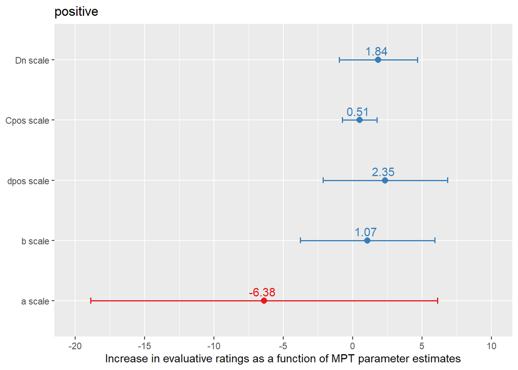

```r
sjPlot::plot_model(mod_pos, show.values = TRUE, width = 0.1)+
  ylab("Increase in evaluative ratings as a function of MPT parameter estimates")
```

```r
sjPlot::tab_model(mod_pos,
          show.intercept = F,
          p.style = "numeric_stars")
```

positive

Predictors

Estimates

CI

p

Dn scale

1.84

-0.98 – 4.67

0.195

Cpos scale

0.51

-0.75 – 1.76

0.419

dpos scale

2.35

-2.14 – 6.83

0.297

b scale

1.07

-3.78 – 5.91

0.660

a scale

-6.38

-18.88 – 6.12

0.309

Observations

49

R<sup>2</sup> / R<sup>2</sup> adjusted

0.113 / 0.010

- p<0.05 ** p<0.01 *** p<0.001

```r
#negative
mod_neg = lm(formula = negative~Dn_scale+Cneg_scale+dneg_scale+b_scale+a_scale
                  ,data = para_ratings
                  )

summary(mod_neg)
```

```
Call:
lm(formula = negative ~ Dn_scale + Cneg_scale + dneg_scale +
    b_scale + a_scale, data = para_ratings)

Residuals:
    Min      1Q  Median      3Q     Max
-1.5727 -0.4876 -0.1252  0.4601  1.5769

Coefficients:
            Estimate Std. Error t value Pr(>|t|)
(Intercept)   5.3282     0.1082  49.237   <2e-16 ***
Dn_scale      1.5247     1.5682   0.972   0.3364
Cneg_scale    1.8932     1.1561   1.638   0.1088
dneg_scale   -0.3834     1.7888  -0.214   0.8313
b_scale       5.5789     2.9678   1.880   0.0669 .
a_scale      -5.2211     7.5167  -0.695   0.4910
---
Signif. codes:  0 '***' 0.001 '**' 0.01 '*' 0.05 '.' 0.1 ' ' 1

Residual standard error: 0.7575 on 43 degrees of freedom
Multiple R-squared:  0.144, Adjusted R-squared:  0.04446
F-statistic: 1.447 on 5 and 43 DF,  p-value: 0.2272
```

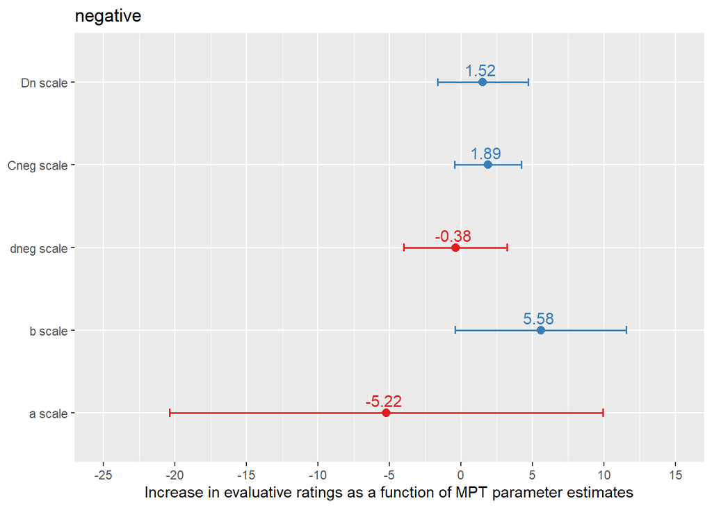

```r
sjPlot::plot_model(mod_neg, show.values = TRUE, width = 0.1)+
  ylab("Increase in evaluative ratings as a function of MPT parameter estimates")
```

```r
sjPlot::tab_model(mod_neg,
          show.intercept = F,
          p.style = "numeric_stars")
```

negative

Predictors

Estimates

CI

p

Dn scale

1.52

-1.64 – 4.69

0.336

Cneg scale

1.89

-0.44 – 4.22

0.109

dneg scale

-0.38

-3.99 – 3.22

0.831

b scale

5.58

-0.41 – 11.56

0.067

a scale

-5.22

-20.38 – 9.94

0.491

Observations

49

R<sup>2</sup> / R<sup>2</sup> adjusted

0.144 / 0.044

- p<0.05 ** p<0.01 *** p<0.001

```r
sjPlot::tab_model(mod_pos, mod_neg,mod_new,
          collapse.ci = TRUE,
          p.style     = "numeric_stars")
```

positive

negative

dist

Predictors

Estimates

p

Estimates

p

Estimates

p

(Intercept)

5.50 ***  
(5.32 – 5.68)

**<0.001**

5.33 ***  
(5.11 – 5.55)

**<0.001**

5.38 ***  
(5.18 – 5.57)

**<0.001**

Dn scale

1.84  
(-0.98 – 4.67)

0.195

1.52  
(-1.64 – 4.69)

0.336

1.02  
(-1.60 – 3.64)

0.436

Cpos scale

0.51  
(-0.75 – 1.76)

0.419

dpos scale

2.35  
(-2.14 – 6.83)

0.297

b scale

1.07  
(-3.78 – 5.91)

0.660

5.58  
(-0.41 – 11.56)

0.067

4.28  
(-0.60 – 9.16)

0.084

a scale

-6.38  
(-18.88 – 6.12)

0.309

-5.22  
(-20.38 – 9.94)

0.491

3.89  
(-6.70 – 14.48)

0.463

Cneg scale

1.89  
(-0.44 – 4.22)

0.109

dneg scale

-0.38  
(-3.99 – 3.22)

0.831

Observations

49

49

49

R<sup>2</sup> / R<sup>2</sup> adjusted

0.113 / 0.010

0.144 / 0.044

0.077 / 0.016

- p<0.05 ** p<0.01 *** p<0.001

# Thematic confusion? Some analyses

```r
#read the file with information regarding each us
us_theme = read.csv("selected_pictures_wsw.csv")

#retrieve the name of each us in the file
us_theme$us_name = paste0(substr(us_theme$valence, 0, 1), us_theme$n)

#combine the two data sets
dat_us = full_join(dat, us_theme, by= c("us"="us_name"))

#explore if recognition accuracy depends on the specific us category/theme
dat_us$Category = as.factor(dat_us$Category)
dat_us$theme = as.factor(dat_us$theme)

dat_us$Category = dat_us$Category %>% str_replace_na("z_new")
dat_us$theme = dat_us$theme %>% str_replace_na("z_new")

table(dat_us$reco_accuracy, dat_us$Category)
```

```
       Animal Object Scene z_new
  cr        0      0     0  1083
  fa        0      0     0    93
  hit     127    178   329     0
  miss    118    116   308     0
```

```r
tab_reco_cat = addmargins(table(dat_us$reco_accuracy, dat_us$Category), 1)

#hit/total
tab_reco_cat[3,]/tab_reco_cat[5,]
```

```
   Animal    Object     Scene     z_new
0.5183673 0.6054422 0.5164835 0.0000000
```

```r
#recognition accuracy seems better for objects than for animals and scenes

table(dat_us$reco_accuracy, dat_us$theme)
```

```
       Beac Bloo Brid Car  Cock Cold Dest Dirt Dog  Elep Fire Flow Gala Garb
  cr      0    0    0    0    0    0    0    0    0    0    0    0    0    0
  fa      0    0    0    0    0    0    0    0    0    0    0    0    0    0
  hit    21   27   24   31   30   32   23   20   21   30   59   34   29   22
  miss   28   22   25   18   19   17   26   29   28   19   39   15   20   27

       Happ Hors Perf Pige Plan Rain Shot Suns War  z_new
  cr      0    0    0    0    0    0    0    0    0  1083
  fa      0    0    0    0    0    0    0    0    0    93
  hit    23   26   30   20   24   32   30   20   26     0
  miss   26   23   19   29   25   17   19   29   23     0
```

```r
tab_reco_theme = addmargins(table(dat_us$reco_accuracy, dat_us$theme), 1)

tab_reco_theme[3,]/tab_reco_theme[5,]
```

```
     Beac      Bloo      Brid      Car       Cock      Cold      Dest      Dirt
0.4285714 0.5510204 0.4897959 0.6326531 0.6122449 0.6530612 0.4693878 0.4081633
     Dog       Elep      Fire      Flow      Gala      Garb      Happ      Hors
0.4285714 0.6122449 0.6020408 0.6938776 0.5918367 0.4489796 0.4693878 0.5306122
     Perf      Pige      Plan      Rain      Shot      Suns      War      z_new
0.6122449 0.4081633 0.4897959 0.6530612 0.6122449 0.4081633 0.5306122 0.0000000
```

```r
#source memory now: whether it was correctly identified as the us or not

dat_us_old = dat_us %>% filter(us_valence != "dist" & reco_resp == "old")

dat_source_us = dat_us_old %>%
  group_by(Category) %>%
  summarize(mean_val_mem = mean(as.numeric(val_us_accuracy_bin))
            ,mean_id_mem = mean(as.numeric(id_us_accuracy_bin)))
dat_source_us
```

```
# A tibble: 3 x 3
  Category mean_val_mem mean_id_mem
  <chr>           <dbl>       <dbl>
1 Animal          0.811       0.646
2 Object          0.860       0.702
3 Scene           0.790       0.599
```

```r
dat_source_us_theme = dat_us_old %>%
  group_by(theme, Category, us) %>%
  summarize(mean_val_mem = mean(as.numeric(val_us_accuracy_bin))
            ,mean_id_mem = mean(as.numeric(id_us_accuracy_bin)))
dat_source_us_theme
```

```
# A tibble: 24 x 5
# Groups:   theme, Category [23]
   theme  Category us    mean_val_mem mean_id_mem
   <chr>  <chr>    <chr>        <dbl>       <dbl>
 1 "Beac" Scene    p11          0.952       0.762
 2 "Bloo" Object   n6           0.852       0.704
 3 "Brid" Scene    p8           0.708       0.625
 4 "Car " Object   n1           0.839       0.613
 5 "Cock" Animal   n12          0.833       0.667
 6 "Cold" Object   p12          0.844       0.75
 7 "Dest" Scene    n2           0.783       0.609
 8 "Dirt" Scene    n10          0.65        0.4
 9 "Dog " Animal   n4           0.905       0.762
10 "Elep" Animal   p3           0.767       0.467
# ... with 14 more rows
```

```r
dat_source_us_theme_sorted = dat_source_us_theme %>%
  as.data.frame() %>%
  arrange(desc(mean_val_mem))
dat_source_us_theme_sorted
```

```
   theme Category  us mean_val_mem mean_id_mem
1   Shot   Object  n9    1.0000000   0.8666667
2   Beac    Scene p11    0.9523810   0.7619048
3   Fire    Scene  n7    0.9310345   0.6896552
4   War     Scene  n3    0.9230769   0.6153846
5   Flow   Object  p2    0.9117647   0.7058824
6   Dog    Animal  n4    0.9047619   0.7619048
7   Fire    Scene  p6    0.8666667   0.6666667
8   Garb    Scene n11    0.8636364   0.6363636
9   Bloo   Object  n6    0.8518519   0.7037037
10  Cold   Object p12    0.8437500   0.7500000
11  Car    Object  n1    0.8387097   0.6129032
12  Cock   Animal n12    0.8333333   0.6666667
13  Hors   Animal  p4    0.8076923   0.7692308
14  Perf    Scene  p1    0.8000000   0.7666667
15  Dest    Scene  n2    0.7826087   0.6086957
16  Elep   Animal  p3    0.7666667   0.4666667
17  Gala    Scene p10    0.7586207   0.6206897
18  Pige   Animal  n8    0.7500000   0.6000000
19  Rain    Scene  p9    0.7500000   0.5312500
20  Brid    Scene  p8    0.7083333   0.6250000
21  Suns    Scene  p5    0.7000000   0.4000000
22  Plan   Object  n5    0.6666667   0.5416667
23  Dirt    Scene n10    0.6500000   0.4000000
24  Happ    Scene  p7    0.5217391   0.3478261
```